# Untitled

24 Februar 2020

## Exercise 3

The file farm.dat contains the size A (in acres), the number of cows C and the income I (in $) of 20 farms in the US. You find the data set on ILIAS.

1. Compute an ordinary linear regression of I versus C. Does the income depend on the number of cows?

```r
farm <- read.table("farm.dat",header = T)
lm1 <- lm(Dollar~cows,farm)
summary(lm1)
```

```
##
## Call:
## lm(formula = Dollar ~ cows, data = farm)
##
## Residuals:
##     Min      1Q  Median      3Q     Max
## -204.68  -80.02   15.48   54.57  284.43
##
## Coefficients:
##             Estimate Std. Error t value Pr(>|t|)
## (Intercept)  694.019     50.039  13.869 4.75e-11 ***
## cows          20.111      4.725   4.256 0.000475 ***
## ---
## Signif. codes:  0 '***' 0.001 '**' 0.01 '*' 0.05 '.' 0.1 ' ' 1
##
## Residual standard error: 122.9 on 18 degrees of freedom
## Multiple R-squared:  0.5016, Adjusted R-squared:  0.4739
## F-statistic: 18.11 on 1 and 18 DF,  p-value: 0.0004751
```

There is a significant p-value of 0.000475 of cows on income.

2. Give the confidence intervals for the expected income without any cows, with 20 cows, and with C = 8.85 cows.

```r
predict(lm1, newdata=data.frame(cows=c(0,20,8.85)), interval="confidence")
```

```
##         fit      lwr       upr
## 1  694.0189 588.8902  799.1476
## 2 1096.2361 971.3953 1221.0768
## 3  872.0000 814.2627  929.7373
```

3. Compute an ordinary linear regression of I versus A and a multiple linear regression of I versus A and C. Also compute the correlation between A and C. Finally, based on your results, explain the differences between the three regression models.

```r
lm2 <- lm(Dollar~acres,farm)
lm3 <- lm(Dollar~cows+acres,farm)
summary(lm2)
```

```
##
## Call:
## lm(formula = Dollar ~ acres, data = farm)
##
## Residuals:
##     Min      1Q  Median      3Q     Max
## -281.54 -113.94  -28.18   94.28  387.05
##
## Coefficients:
##             Estimate Std. Error t value Pr(>|t|)
## (Intercept) 868.7363   105.9796   8.197 1.73e-07 ***
## acres         0.0234     0.7066   0.033    0.974
## ---
## Signif. codes:  0 '***' 0.001 '**' 0.01 '*' 0.05 '.' 0.1 ' ' 1
##
## Residual standard error: 174.1 on 18 degrees of freedom
## Multiple R-squared:  6.09e-05,   Adjusted R-squared:  -0.05549
## F-statistic: 0.001096 on 1 and 18 DF,  p-value: 0.974
```

```r
summary(lm3)
```

```
##
## Call:
## lm(formula = Dollar ~ cows + acres, data = farm)
##
## Residuals:
##      Min       1Q   Median       3Q      Max
## -145.064  -46.719   -9.992   55.149  133.664
##
## Coefficients:
##             Estimate Std. Error t value Pr(>|t|)
## (Intercept) 285.4572    81.3793   3.508   0.0027 **
## cows         32.5690     3.7276   8.737 1.08e-07 ***
## acres         2.1384     0.3936   5.434 4.47e-05 ***
## ---
## Signif. codes:  0 '***' 0.001 '**' 0.01 '*' 0.05 '.' 0.1 ' ' 1
##
## Residual standard error: 76.45 on 17 degrees of freedom
## Multiple R-squared:  0.8179, Adjusted R-squared:  0.7965
## F-statistic: 38.17 on 2 and 17 DF,  p-value: 5.165e-07
```

```r
cor(farm$cows,farm$acres)
```

```
## [1] -0.615085
```

## Exercise 4

In this exercise, we again consider the air pollution data set presented in the lecture. In a study on the contribution of air pollution to mortality, General Motors collected data from 60 US cities. The dependent variable is the age adjusted mortality (variable Mortality). The data includes variables measuring demographic characteristics of the cities, variables measuring climate characteristics, and variables recording the pollution potential of three different air pollutants.

1. Get an overview of the data and account for possible problems. Which of the variables need to be transformed?

```
##                                      City Mortality JanTemp JulyTemp RelHum
## 1                               Akron, OH    921.87      27       71     59
## 2             Albany-Schenectady-Troy, NY    997.87      23       72     57
## 3              Allentown, Bethlehem,PA-NJ    962.35      29       74     54
## 4                             Atlanta, GA    982.29      45       79     56
## 5                           Baltimore, MD   1071.29      35       77     55
## 6                          Birmingham, AL   1030.38      45       80     54
## 7                              Boston, MA    934.70      30       74     56
## 8                  Bridgeport-Milford, CT    899.53      30       73     56
## 9                             Buffalo, NY   1001.90      24       70     61
## 10                             Canton, OH    912.35      27       72     59
## 11                     Chattanooga, TN-GA   1017.61      42       79     56
## 12                            Chicago, IL   1024.89      26       76     58
## 13                   Cincinnati, OH-KY-IN    970.47      34       77     57
## 14                          Cleveland, OH    985.95      28       71     60
```

[output cut: 105 more lines]

```
## [1] 59 16
```

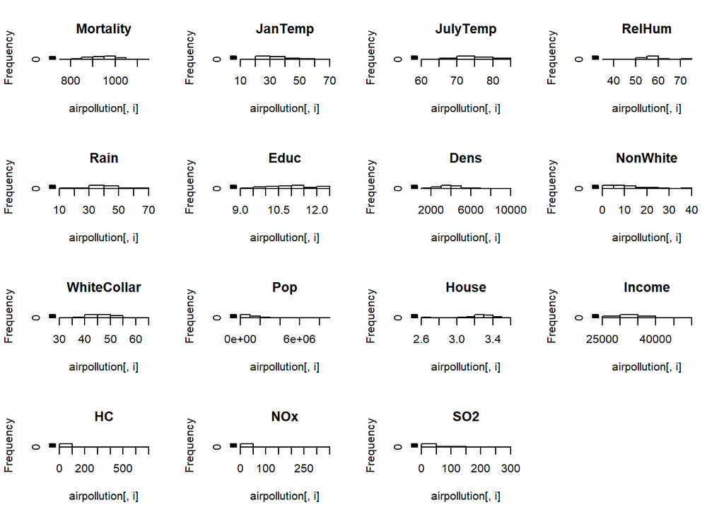

Transform the following traits:

```r
airpollution$Pop <- log(airpollution$Pop)
airpollution$HC <- log(airpollution$HC)
airpollution$NOx <- log(airpollution$NOx)
airpollution$SO2 <- log(airpollution$SO2)

names(airpollution)[names(airpollution)=="Pop"]<-"logPop"
names(airpollution)[names(airpollution)=="HC"]<- "logHC"
names(airpollution)[names(airpollution)=="NOx"]<-"logNOx"
names(airpollution)[names(airpollution)=="SO2"]<-"logSO2"
```

2. Carry out a multiple linear regression containing all variables. Does the model fit well? Check the residuals.

```r
# Exclude the city names
airpollution <- airpollution[,c(2:length(airpollution))]
# Calculate the Multiple linear regression model
lmairpollution <- lm(Mortality~.,airpollution)
summary(lmairpollution)
```

```
##
## Call:
## lm(formula = Mortality ~ ., data = airpollution)
##
## Residuals:
##     Min      1Q  Median      3Q     Max
## -68.893 -20.704   0.586  24.129  74.604
##
## Coefficients:
##               Estimate Std. Error t value Pr(>|t|)
## (Intercept)  1.297e+03  2.934e+02   4.422 6.32e-05 ***
## JanTemp     -2.368e+00  8.851e-01  -2.676   0.0104 *
## JulyTemp    -1.752e+00  2.031e+00  -0.863   0.3931
## RelHum       3.420e-01  1.059e+00   0.323   0.7482
## Rain         1.493e+00  5.898e-01   2.532   0.0150 *
## Educ        -1.000e+01  9.087e+00  -1.101   0.2771
## Dens         4.525e-03  4.223e-03   1.072   0.2897
## NonWhite     5.152e+00  1.002e+00   5.143 6.01e-06 ***
## WhiteCollar -1.883e+00  1.198e+00  -1.572   0.1232
## logPop       4.391e+00  7.714e+00   0.569   0.5721
## House       -4.574e+01  3.939e+01  -1.161   0.2518
## Income      -6.892e-04  1.334e-03  -0.516   0.6081
## logHC       -2.204e+01  1.523e+01  -1.447   0.1550
## logNOx       3.397e+01  1.425e+01   2.384   0.0215 *
## logSO2      -3.687e+00  7.359e+00  -0.501   0.6189
## ---
## Signif. codes:  0 '***' 0.001 '**' 0.01 '*' 0.05 '.' 0.1 ' ' 1
##
## Residual standard error: 34.48 on 44 degrees of freedom
## Multiple R-squared:  0.7685, Adjusted R-squared:  0.6949
## F-statistic: 10.43 on 14 and 44 DF,  p-value: 8.793e-10
```

Check the fit of the model:

```r
library(car)
```

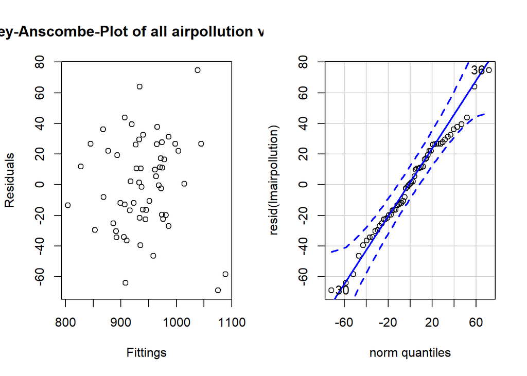

```
## [1] 36 30
```

```r
par(mfrow=c(1,2))
#par(mfrow = c(1, 2), mar = c(1.5, 2, 1.5, 0.5), cex = 0.5)
plot(fitted(lmairpollution),resid(lmairpollution),xlab = "Fittings",ylab = "Residuals",main = "Tukey-Anscombe-Plot of all airpollution variables")
qqPlot(resid(lmairpollution),dist="norm",mean=mean(resid(lmairpollution)),sd=sd(resid(lmairpollution)))
```

The model seems to fit very well. Not all variables are significant.

3. Now take all the non-significant variables out of the model and compute the regression again. Compare your results to part b.).

```r
lmap_sign <- lm(Mortality~JanTemp+Rain+NonWhite+logNOx,airpollution)
summary(lmap_sign)
```

```
##
## Call:
## lm(formula = Mortality ~ JanTemp + Rain + NonWhite + logNOx,
##     data = airpollution)
##
## Residuals:
##     Min      1Q  Median      3Q     Max
## -64.946 -22.658  -1.435  19.769  92.049
##
## Coefficients:
##             Estimate Std. Error t value Pr(>|t|)
## (Intercept) 838.1347    27.9499  29.987  < 2e-16 ***
## JanTemp      -2.4322     0.5220  -4.659 2.11e-05 ***
## Rain          2.2528     0.4857   4.639 2.27e-05 ***
## NonWhite      4.3129     0.6479   6.657 1.48e-08 ***
## logNOx       20.2033     4.6113   4.381 5.47e-05 ***
## ---
## Signif. codes:  0 '***' 0.001 '**' 0.01 '*' 0.05 '.' 0.1 ' ' 1
##
## Residual standard error: 35.62 on 54 degrees of freedom
## Multiple R-squared:  0.6968, Adjusted R-squared:  0.6743
## F-statistic: 31.02 on 4 and 54 DF,  p-value: 2.018e-13
```

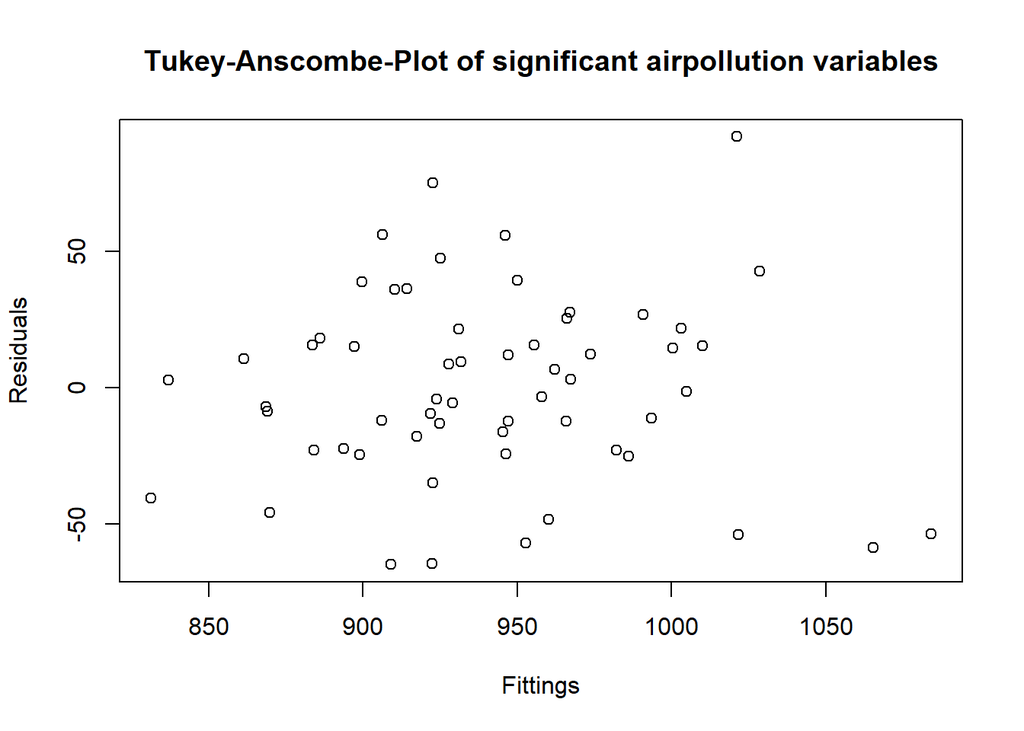

```r
plot(fitted(lmap_sign),resid(lmap_sign),xlab = "Fittings",ylab = "Residuals",main = "Tukey-Anscombe-Plot of significant airpollution variables")
```

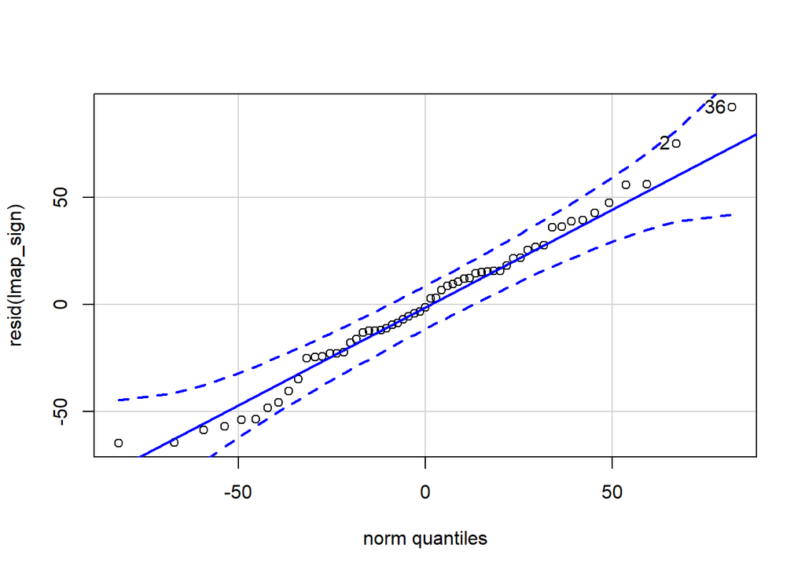

```
## [1] 36  2
```

```r
qqPlot(resid(lmap_sign),dist="norm",mean=mean(resid(lmap_sign)),sd=sd(resid(lmap_sign)))
```

All variables are now highly significant. The model also looks well, all criterias fullfilled.